# ES207_hw4_Guo

4. The Everglades wetland ecosystems are phosphorus limited. After the Everglades Agriculture Areas (EAA) were established (enabled by a series of federal government constructed water diversion systems for draining part of the Everglades wetland), phosphorus-rich agriculture runoff reached the Everglades wetland and resulted in dramatic changes in parts of the Everglades wetlands. To better protect the Everglades, many studies were conducted in the late 1980s and the 1990s to learn about the effects of phosphorus enrichment in the Everglades. One study focused on estimating the background level of phosphorus concentration. To identify which site is not affected by the agriculture runoff, researchers measured phosphatase activity (APA) in sites known to be affected (TP > 30 ug/L) and sites that are unaffected by agriculture runoff. Phosphatase is an enzyme produced by organisms in low P environment. Because producing this enzyme costs energy, organisms do not produce them when bio-available phosphorus are present. As a result, high APA is an indicator of P limitation. The data file apa.s contains both APA and TP concentrations. It can be imported into R using function source.
1. Compare the distributions of APA from sites with TP > 30 ug/L and APA from sites with TP < 30 ug/L using graphical tools we learned in Chapter 3.

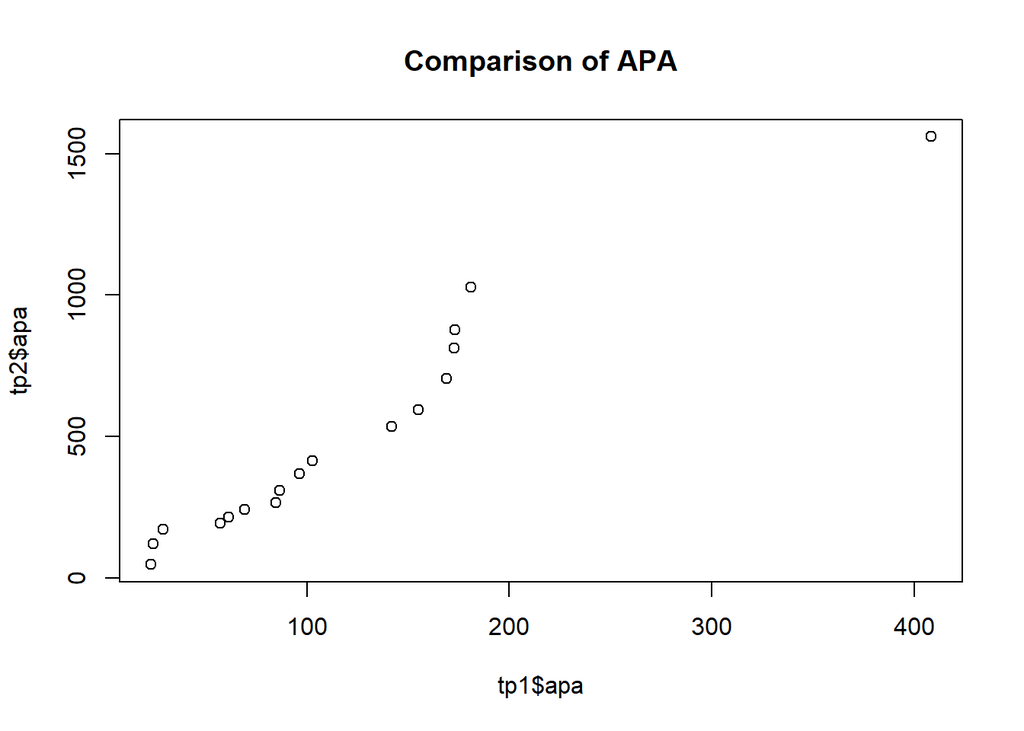

```r
apa <- source('apa.s')
tp1 <- apa$value %>% filter(tp > 30)
tp2 <- apa$value %>% filter(tp <= 30)
qqplot(tp1$apa, tp2$apa, plot.it = TRUE, main="Comparison of APA")
```

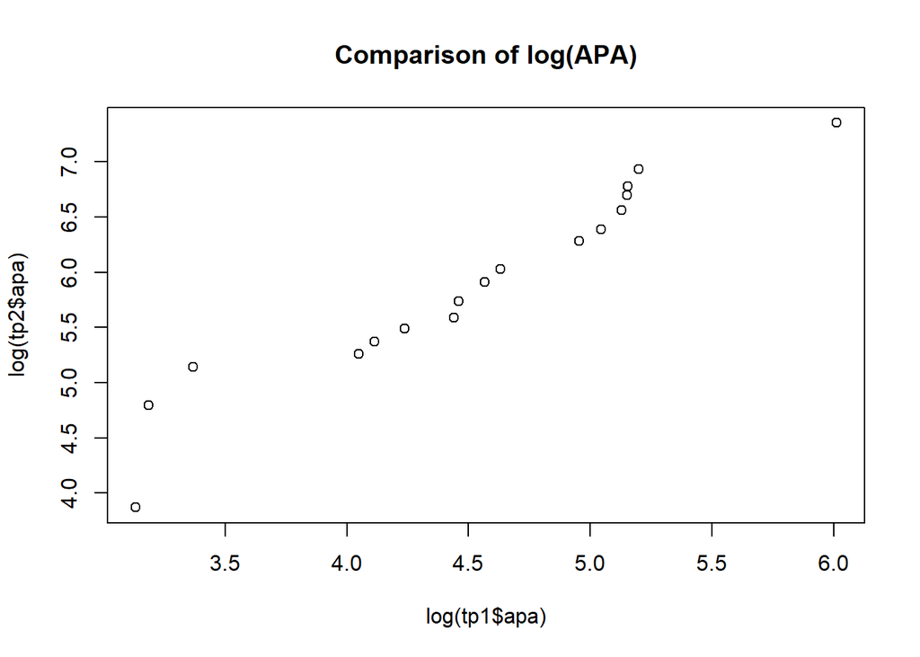

```r
qqplot(log(tp1$apa), log(tp2$apa), plot.it = TRUE, main="Comparison of log(APA)")
```

2. What is the nature of difference between the two populations of APA?

From the qqplot above, the logarithm one is closer to a straight line. So it is more likely to be multiplicative relationship between the two sets of APA data.

3. Use an appropriate test to determine whether the difference is statistically signiffcant and describe the result in non-technical terms.

```r
t.test(tp1$apa, tp2$apa, paired = FALSE, conf.level=0.95)
```

```
##
##  Welch Two Sample t-test
##
## data:  tp1$apa and tp2$apa
## t = -8.7819, df = 91.867, p-value = 8.428e-14
## alternative hypothesis: true difference in means is not equal to 0
## 95 percent confidence interval:
##  -435.8935 -275.0950
## sample estimates:
## mean of x mean of y
##  119.7532  475.2474
```

We can see from the T-test, the p-value here is very small, which is p-value = 8.428e-14, so that means those two sets of data are significantly different, less than 8.428e-14 probabality that they are just random and not significantly different.